# Exploratory Data Analysis Tutorial – Dietary Bioactives, SCFAs, Metabolites, and Microbiome

Boxplots and heatmaps of the microbiome, bioactive, and SCFA data

## Overview

This tutorial covers the main exploratory and differential analyses in the DIME paper, corresponding to **Figure 3** panels A-C, as well as a few other plots.

## Note on using AI

This tutorial has A LOT of code in it. You can certainly use AI to play around with the code and data, however, please make sure you are really learning something while you do that!

## 1 Load packages

```r
library(tidyverse)
library(pheatmap)   # pheatmap::pheatmap for heatmaps
library(ggrepel)    # ggrepel::geom_text_repel for volcano labels
library(readxl)     # readxl::read_xlsx for metabolite data
library(ggpubr)     # ggpubr::stat_compare_means for significance brackets

source("../R/data.R")    # read_metadata(), read_taxa(), read_food_composition()
source("../R/theme.R")   # BIOACTIVE_COLORS, BIOACTIVE_COLORS3, THEME_DIME

# We also source metabolites.R later, only for the SCFA correlation functions
```

## 2 Load Metadata

Let’s look at the metadata first. We’ll also add a column that signifies what kind of diet the participant had just finished:

- “baseline” for before their first diet, representative of their prior microbiome
- “before second diet” just after the midpoint phase, before starting their alternative diet
- “high / low bioactive” depending on which diet they’d just finished
- “midpoint” during the middle washout phase

```r
# --- Metadata ---
tbl_md <- read_metadata("../data/source/sample_metadata.csv")

# Helper: add Diet column.
tbl_md <- tbl_md |>
  mutate(Diet = case_when(
    baseline                   ~ "Baseline",
    sample_arm == "after_high" ~ "High Bioactive",
    sample_arm == "after_low"  ~ "Low Bioactive",
    sample_arm == "midpoint"   ~ "Midpoint",
    TRUE                       ~ "Before Second Diet"
  ))


head(tbl_md)
```

```
## # A tibble: 6 × 9
##   sample_id participant time_point sample_group sample_arm  sequence diet
##   <chr>     <chr>       <chr>      <chr>        <chr>       <chr>    <chr>
## 1 01-MP     01          MP         midpoint     midpoint    low_high midpoint
## 2 01-V1     01          V1         before       before_low  low_high low
## 3 01-V2     01          V2         after        after_low   low_high low
## 4 01-V3     01          V3         before       before_high low_high high
## 5 01-V4     01          V4         after        after_high  low_high high
## 6 02-MP     02          MP         midpoint     midpoint    high_low midpoint
## # ℹ 2 more variables: baseline <lgl>, Diet <chr>
```

**Exercises:**

- Find out a few simple statistics about the metadata. How many different participants are there? How many are in the `low_high` arm, and how many in the `high_low` arm? Do all participants have 5 timepoints?
- We’re using a helper function `read_metadata` here - it comes from the file `R/data.R`. Take a look at that file and search for it - `read_metadata` is just a simple function which reads the metadata table and adds another column. How is it doing that?

We’ll use a few helper functions like this during the tutorial (mainly to save a bit of time), and flag them up when we do.

## 3 Bioactive intake by diet arm

The study compared a High Bioactive (HB) diet rich in plant bioactives against a Low Bioactive (LB) diet. Let’s look at the dietary intakes on each diet, and confirm that the diets really were very different.

We’ll first load some of the diet data, again using a handy helper function.

```r
# --- Dietary intakes (residual-adjusted) ---
# read_food_composition() reads the TSV and splits columns into nutrients
# vs bioactives using the nutrient reference file — similar to read_taxa().
lst_diet <- read_food_composition(
  "../data/source/diet/residual_adjusted.tsv",
  "../data/source/diet/nutrient_diet.tsv"
)
# lst_diet$bioactive is a matrix: bioactives x samples

lst_diet$bioactive |> as.data.frame() |> head()
```

```
##                      01-V1      02-V1       04-V1       05-V1       06-V1
## Lignans          0.3529648  0.9524476   0.8235175    1.423763   0.6659397
## Isoflavones     -0.2462026  0.2849053   1.0987293    3.252674   2.6949857
## Phytosterol     62.0047609 36.0838251  18.8067606   -1.037040  21.6562134
## Proanthocyanins 34.7127117 46.0902665  29.2932493   87.723496  28.9425426
## Lycopene         0.1538044  0.2918515   0.4548373    2.860180  -0.3086051
## Anthocyanins    53.0307907 46.9420160 -65.1251589 -166.710156 398.7072626
##                      07-V1       09-V1       13-V1       14-V1       15-V1
## Lignans          0.1654085   3.9541030  0.05647071   0.7395084   1.7157388
## Isoflavones     -0.7282851  -0.2789176 -1.18298417  -1.4999455   0.4696971
## Phytosterol     39.9693006  59.4659918 19.09850017  89.3383389 108.6271835
## Proanthocyanins 31.7083911  68.1696778  2.51288685  96.7874871  14.5127904
## Lycopene         0.6322180   8.4044564  0.26525212   0.7650623   5.7225189
## Anthocyanins    63.7488715 575.2713389 82.47567144 112.8197532 197.9174009
##                       16-V1       18-V1        19-V1       20-V1       21-V1
## Lignans           0.1521749   1.0890048 -0.001702895  -0.1084357   1.1963109
## Isoflavones      -0.4214340  -2.7444525 -1.279995880  33.3849973  -0.4122868
## Phytosterol      20.4755671  37.3208362 35.329904864  22.5489526  43.3403662
## Proanthocyanins  -1.1849382 -11.8983803  6.667902575  14.0685031  19.0210386
## Lycopene          0.9949088   0.5845349  0.148067821   0.3677384   0.6987276
## Anthocyanins    142.1541153 436.5300767 81.663330689 168.2057636 274.4066507
##                      22-V1         23-V1      24-V1      25-V1      27-V1
## Lignans          0.1755125   0.001076373  0.4384845  0.6699428  1.2179740
## Isoflavones      0.1563749  -1.672351063 -0.5473913  0.9674726  0.1760827
## Phytosterol     15.2493814  46.717880103 62.0436829 83.1188258 67.6096026
## Proanthocyanins  0.9767328  25.225343768 73.3806320 36.7183674 72.6033982
## Lycopene         0.3872525   0.599039475  1.3884826  0.9828280  2.4010859
## Anthocyanins    -8.3256686 123.355052262 75.2136492 45.4244617 32.7812970
##                        01-V2        02-V2        04-V2        05-V2
## Lignans           1.22911996    1.0335880   1.53515973    1.9356450
## Isoflavones       0.51110762    0.4254995   0.77726521    2.2456842
## Phytosterol      78.56618036   21.4614234 151.85017812   12.6328344
## Proanthocyanins   1.66368101   39.7891817   3.43948391   40.4384738
## Lycopene         -0.04238268    0.1545318  -0.08762313    0.3992476
## Anthocyanins    -22.72258651 3855.3277802 -34.85640815 3177.3577668
##                        06-V2        07-V2        09-V2        13-V2
## Lignans            0.6526193    1.5757218    7.9456824    1.0505462
## Isoflavones       -0.2817604   -0.5877252   89.8823851    1.0608823
## Phytosterol      105.8741299   31.3911770   26.3554830   26.0530326
## Proanthocyanins  364.1590756   23.6890496    0.2340798   28.3048409
```

[output cut: 36 more lines]

```
## Anthocyanins    69.00681506 -102.8098279 -99.7744855 3588.121731 235.1470523
##                       20-V4        21-V4        22-V4        23-V4        24-V4
## Lignans           0.7099188    3.1911246    2.8644742    2.0097246    0.2721507
## Isoflavones      -0.7916234   -0.4446282   -0.1002606   -0.3857402    1.7900153
## Phytosterol     102.1543703   80.4264185   58.0340524   72.7524924   91.6266142
## Proanthocyanins  -3.7720976    7.7141622   53.8803501   18.2644279    7.9495667
## Lycopene          0.1005551    0.8457657    1.4997028    0.5806946   -0.1962792
## Anthocyanins     68.5542450 2940.9758628 2912.2192976 3502.9917354 -110.1805141
##                        25-V4       27-V4
## Lignans            0.5445118   0.6130795
## Isoflavones        2.3480138   1.0499221
## Phytosterol       47.5417140 140.1668693
## Proanthocyanins   10.5052166   4.6316076
## Lycopene          -0.2660261  -0.1174210
## Anthocyanins    -146.0816401 -49.3612284
```

We’re going to plot the amount of bioactives that were found within different sample arms. Take a look at the DIME paper (Supplementary Information) line 5 to get an idea of what we’re aiming for.

We’ll be making a lot of boxplots using ggplot. First we need to join the metadata to our diet information table.

```r
# The bioactive matrix has compounds on rows, samples on columns.
# Pivot to long format and join metadata.
tbl_bioactive_long <- lst_diet$bioactive |>
  as.data.frame() |>
  rownames_to_column("bioactive") |>
  pivot_longer(-bioactive, names_to = "sample_id", values_to = "intake") |>
  left_join(tbl_md, by = "sample_id")

head(tbl_bioactive_long)
```

```
## # A tibble: 6 × 11
##   bioactive sample_id intake participant time_point sample_group sample_arm
##   <chr>     <chr>      <dbl> <chr>       <chr>      <chr>        <chr>
## 1 Lignans   01-V1      0.353 01          V1         before       before_low
## 2 Lignans   02-V1      0.952 02          V1         before       before_high
## 3 Lignans   04-V1      0.824 04          V1         before       before_low
## 4 Lignans   05-V1      1.42  05          V1         before       before_high
## 5 Lignans   06-V1      0.666 06          V1         before       before_high
## 6 Lignans   07-V1      0.165 07          V1         before       before_high
## # ℹ 4 more variables: sequence <chr>, diet <chr>, baseline <lgl>, Diet <chr>
```

Now we’ll build our boxplots. The full code is below but you might prefer to build the boxplots up, running the code line-by-line.

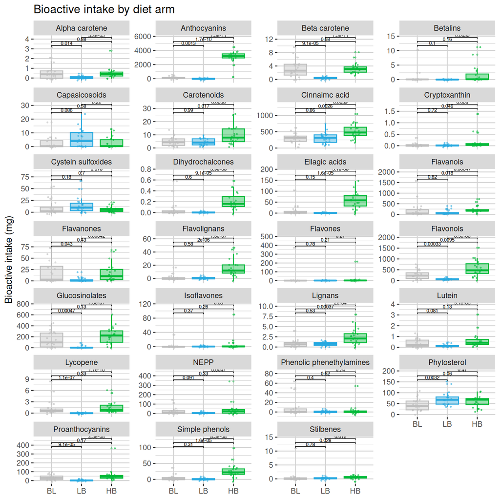

```r
ggplot(tbl_bioactive_long,
       aes(x = Diet, y = intake, colour = Diet, fill = Diet)) +
  geom_boxplot(alpha = 0.4, outlier.size = 0.5, show.legend = FALSE) +
  geom_jitter(width = 0.15, size = 0.4, alpha = 0.5, show.legend = FALSE) +
  facet_wrap(~bioactive, scales = "free_y", ncol = 4) +
  scale_x_discrete(
    limits = c("Baseline", "Low Bioactive", "High Bioactive"),
    labels = c("BL", "LB", "HB")
  ) +
  labs(
    title  = "Bioactive intake by diet arm",
    x = NULL, y = "Bioactive intake (mg)"
  ) +
  ggpubr::stat_compare_means(
    comparisons = list(
      c("Baseline", "Low Bioactive"),
      c("Baseline", "High Bioactive"),
      c("Low Bioactive", "High Bioactive")
    ), method = "wilcox.test", size = 2
  ) +
  scale_colour_manual(values = BIOACTIVE_COLORS3) +
  scale_fill_manual(values = BIOACTIVE_COLORS3) +
  THEME_DIME
```

The high bioactive diet is very clearly working as intended. It’s a bit surprising to me how similar the low bioactive and baseline distributions are for a lot of these compounds; though there are also some obvious differences.

**Exercise**:

- This boxplot shows every single bioactive in a different subplot. If you just want a single boxplot showing overall (total) bioactive intake per study arm, how can we do that?

## 4 SCFA boxplots — Figure 3, Panel B

Short-chain fatty acids (SCFAs) are produced by gut bacteria fermenting dietary fibre. We compare concentrations of Acetate, Propionate, and Butyrate (the three shortest SCFAs) between Baseline, Low Bioactive, and High Bioactive conditions.

```r
# --- SCFAs ---
tbl_scfa <- read_delim(
                       "../data/source/scfa/SCFA_DIME.csv",
                       show_col_types = FALSE)

tbl_scfa |> head()
```

```
## # A tibble: 6 × 11
##   ID    Acetate Propionate Butyrate Isobutyrate `2-methylbutyrate`
##   <chr>   <dbl>      <dbl>    <dbl>       <dbl>              <dbl>
## 1 27-V4   7.63       0.837   0.687       0.0223             0.0264
## 2 09-MP   1.54       0.271   0.155       0.0182             0.0333
## 3 04-V2   1.93       0.102   0.116       0.0093             0.0129
## 4 24-V2   0.845      0.223   0.0315      0.0147             0.0331
## 5 16-V4   3.36       0.373   0.357       0.0158             0.0288
## 6 24-MP   1.21       0.130   0.157       0.0057             0.0096
## # ℹ 5 more variables: ` Isovalerate` <dbl>, Valerate <dbl>,
## #   `3-methylvalerate` <dbl>, Isocaproate <dbl>, Caproate <dbl>
```

We’re only interested in values after the diets - so we join this table with the metadata and then filter; finally we select just the columns we need for the boxplots.

```r
# The SCFA file has a column called ID (= sample_id) and one column per SCFA
tbl_scfa_long <- tbl_scfa |>
  rename(sample_id = ID) |>
  left_join(tbl_md, by = "sample_id") |>
  filter(sample_arm %in% c("after_high", "after_low") | baseline) |>
  select(participant, Diet, Acetate:Butyrate) |>
  pivot_longer(Acetate:Butyrate, names_to = "SCFA", values_to = "concentration")


tbl_scfa_long
```

```
## # A tibble: 180 × 4
##    participant Diet           SCFA       concentration
##    <chr>       <chr>          <chr>              <dbl>
##  1 27          Low Bioactive  Acetate           7.63
##  2 27          Low Bioactive  Propionate        0.837
##  3 27          Low Bioactive  Butyrate          0.687
##  4 04          Low Bioactive  Acetate           1.93
##  5 04          Low Bioactive  Propionate        0.102
##  6 04          Low Bioactive  Butyrate          0.116
##  7 24          High Bioactive Acetate           0.845
##  8 24          High Bioactive Propionate        0.223
##  9 24          High Bioactive Butyrate          0.0315
## 10 16          Low Bioactive  Acetate           3.36
## # ℹ 170 more rows
```

Once again, we’ll build up the boxplots; it may help to run through the code line-by-line. We don’t find any significant differences between the low and high bioactive groups. **Exercise:** If you have time, edit the code (and the block above) to look through some of the other SCFAs.

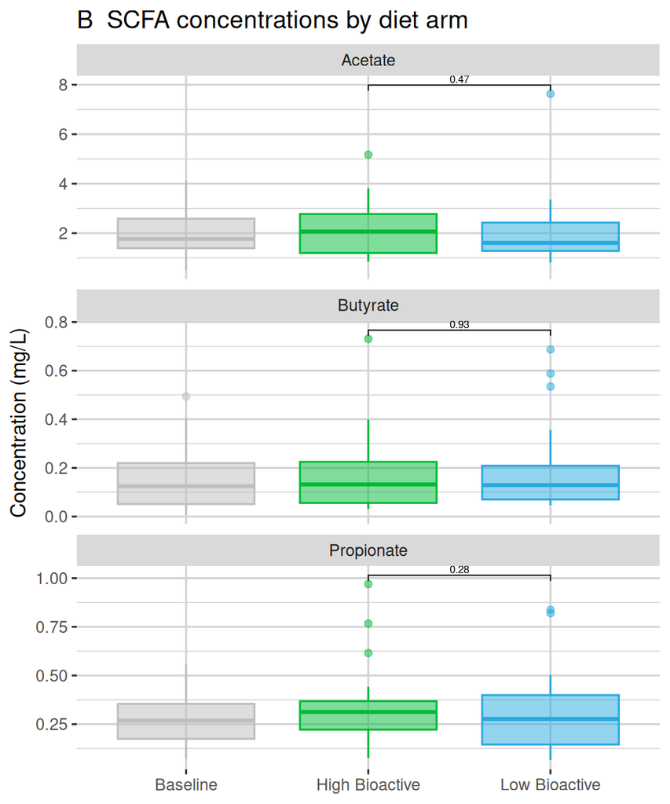

```r
ggplot(tbl_scfa_long,
       aes(x = Diet, y = concentration, fill = Diet, colour = Diet)) +
  geom_boxplot(alpha = 0.5, show.legend = FALSE) +
  facet_wrap(~SCFA, ncol = 1, scales = "free_y") +
  ggpubr::stat_compare_means(
    comparisons = list(c("Low Bioactive", "High Bioactive")),
    method = "wilcox.test", paired = TRUE, size = 2,
    symnum.args = list(
      cutpoints = c(0, 0.001, 0.01, 0.05, Inf),
      symbols   = c("***", "**", "*", "ns")
    )
  ) +
  labs(
    title = "B  SCFA concentrations by diet arm",
    x = NULL, y = "Concentration (mg/L)"
  ) +
  scale_fill_manual(values = BIOACTIVE_COLORS3) +
  scale_colour_manual(values = BIOACTIVE_COLORS3) +
  THEME_DIME
```

## 5 SCFA–bioactive correlation heatmap — Figure 3, Panel C

We test whether SCFA concentrations correlate with bioactive intake within each diet arm. To save time, and quite a lot of work, we’ll use a helper function, in “R/metabolites.R”. Look at the code in `scfa_bioactive_correlation()` and `plot_scfa_bioactive_correlation()` helpers, which loop over SCFA x bioactive pairs, compute Pearson correlations and BH-adjusted q-values, and visualise the result as a heatmap.

```r
source("../R/metabolites.R")


lst_scfa_corr <- scfa_bioactive_correlation(
  tbl_scfa       = tbl_scfa,
  tbl_bioactive  = lst_diet$bioactive,
  tbl_sample_metadata = tbl_md
)
# Returns a list with $high_bioactive and $low_bioactive correlation tables
head(lst_scfa_corr$high_bioactive)
```

```
##              scfa       bioactive   pearson_r pearson_p spearman_rho spearman_p
## Acetate   Acetate         Lignans  0.13536573 0.5693398  -0.06315789  0.7917740
## Acetate.1 Acetate     Isoflavones  0.10837225 0.6492587   0.16090226  0.4963718
## Acetate.2 Acetate     Phytosterol  0.09972671 0.6757133  -0.03308271  0.8912641
## Acetate.3 Acetate Proanthocyanins  0.05589682 0.8149348   0.01654135  0.9467781
## Acetate.4 Acetate        Lycopene -0.01880340 0.9372845  -0.11278195  0.6350108
## Acetate.5 Acetate    Anthocyanins -0.13997809 0.5561274  -0.26315789  0.2611627
##           pearson_q spearman_q
## Acetate   0.9899308  0.9774019
## Acetate.1 0.9899308  0.9774019
## Acetate.2 0.9899308  0.9774019
## Acetate.3 0.9899308  0.9869421
## Acetate.4 0.9899308  0.9774019
## Acetate.5 0.9899308  0.9774019
```

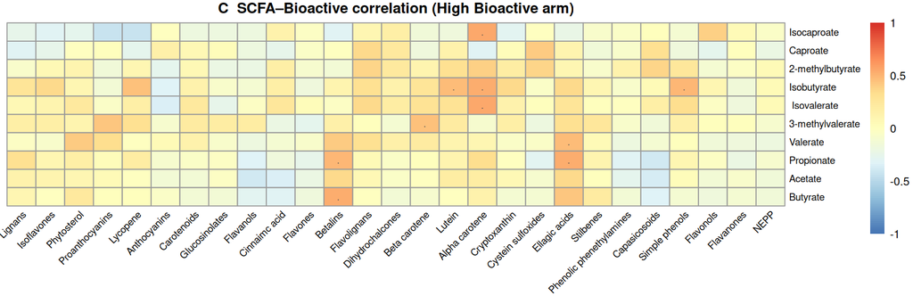

```r
plt_scfa_heatmap <- plot_scfa_bioactive_correlation(
  lst_scfa_corr$high_bioactive,
  main       = "C  SCFA–Bioactive correlation (High Bioactive arm)",
  fontsize   = 8,
  fontsize_row = 7,
  fontsize_col = 7,
  angle_col  = 45
)
```

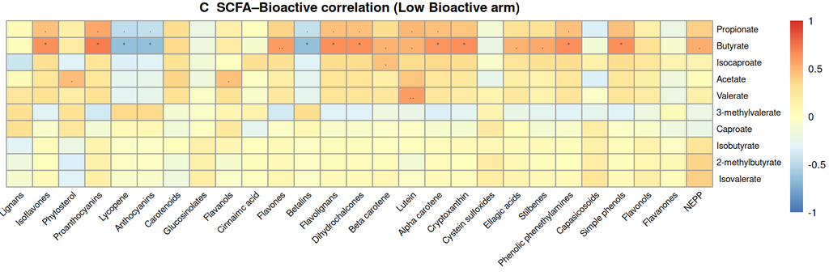

```r
plt_scfa_heatmap <- plot_scfa_bioactive_correlation(
  lst_scfa_corr$low_bioactive,
  main       = "C  SCFA–Bioactive correlation (Low Bioactive arm)",
  fontsize   = 8,
  fontsize_row = 7,
  fontsize_col = 7,
  angle_col  = 45
)
```

## 6 Genus-level abundance heatmap

```r
# --- Genus-level microbiome (L5 = genus) ---
tbl_genus <- read_taxa("../data/source/microbiome/taxa/MGS.matL5.txt") |>
  order_table()

tbl_genus |> head()
```

```
## # A tibble: 6 × 101
##   L5     `01-V1` `02-V1` `04-V1` `05-V1` `06-V1` `07-V1` `09-V1` `13-V1` `14-V1`
##   <chr>    <dbl>   <dbl>   <dbl>   <dbl>   <dbl>   <dbl>   <dbl>   <dbl>   <dbl>
## 1 Bacte…     0         0    0          0       0       0      0        0       0
## 2 Bacte…     0         0    0          0       0       0      0        0       0
## 3 Bacte…     0         0   86.4        0       0       0    901.       0       0
## 4 Bacte…     0         0    1.52       0       0       0      0        0       0
## 5 Bacte…     0         0    3.40       0       0       0      0        0       0
## 6 Bacte…    60.3       0    0          0       0       0      0        0       0
## # ℹ 91 more variables: `15-V1` <dbl>, `16-V1` <dbl>, `18-V1` <dbl>,
## #   `19-V1` <dbl>, `20-V1` <dbl>, `21-V1` <dbl>, `22-V1` <dbl>, `23-V1` <dbl>,
## #   `24-V1` <dbl>, `25-V1` <dbl>, `27-V1` <dbl>, `01-V2` <dbl>, `02-V2` <dbl>,
## #   `04-V2` <dbl>, `05-V2` <dbl>, `06-V2` <dbl>, `07-V2` <dbl>, `09-V2` <dbl>,
## #   `13-V2` <dbl>, `14-V2` <dbl>, `15-V2` <dbl>, `16-V2` <dbl>, `18-V2` <dbl>,
## #   `19-V2` <dbl>, `20-V2` <dbl>, `21-V2` <dbl>, `22-V2` <dbl>, `23-V2` <dbl>,
## #   `24-V2` <dbl>, `25-V2` <dbl>, `27-V2` <dbl>, `01-MP` <dbl>, …
```

First, we’ll take a look at the table, and apply total-sum-scaling.

```r
genus_col <- colnames(tbl_genus)[1]

genus_rel <- tbl_genus |>
  column_to_rownames(genus_col) |>
  as.matrix() |>
  prop.table(margin = 2)   # TSS: column proportions
```

Now let’s select the top 30 genera, and also tidy up their names.

```r
# Mean relative abundance across post-intervention samples
mean_abund <- rowMeans(genus_rel)

# Keep top 30; trim the lineage string to genus name only
top_genera <- sort(mean_abund, decreasing = TRUE)[1:30] |> names()

trim_to_genus <- function(x) {
  parts <- strsplit(x, ";", fixed = TRUE)[[1]]
  # Last non-'?' level
  known <- parts[parts != "?"]
  tail(known, 1)
}

genus_mat <- genus_rel[top_genera, ]
rownames(genus_mat) <- map_chr(top_genera, trim_to_genus)
```

Finally, we’re using the `pheatmap` function to draw the heatmap.

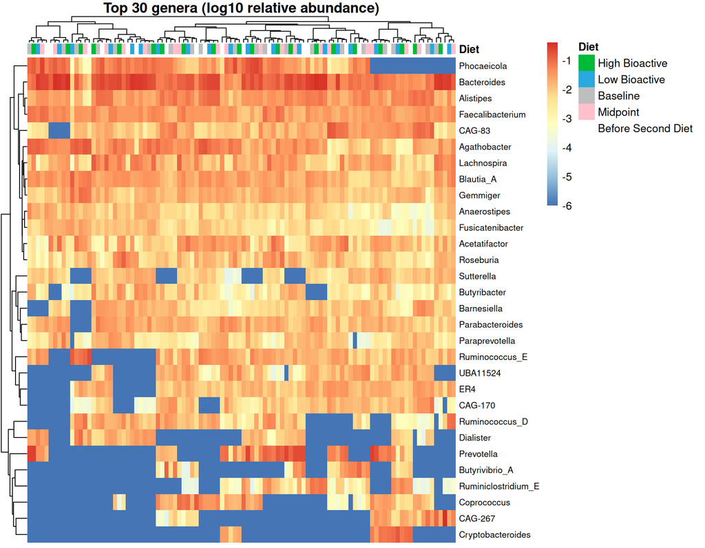

```r
# Column annotation: which diet arm is each sample?
col_annot <- tbl_md |>
  select(sample_id, Diet) |>
  column_to_rownames("sample_id")

annot_colours <- list(
  Diet = c(
    "High Bioactive" = unname(BIOACTIVE_COLORS3["High Bioactive"]),
    "Low Bioactive"  = unname(BIOACTIVE_COLORS3["Low Bioactive"]),
    "Baseline"       = unname(BIOACTIVE_COLORS3["Baseline"]),
    "Midpoint"       = "pink",
    "Before Second Diet" = "white"
  )
)

pheatmap::pheatmap(
  log10(genus_mat + 1e-6),    # log-transform for visual range
  annotation_col  = col_annot,
  annotation_colors = annot_colours,
  cluster_rows    = TRUE,
  cluster_cols    = TRUE,
  show_colnames   = FALSE,
  fontsize_row    = 8,
  treeheight_row  = 20,
  treeheight_col  = 20,
  main = "Top 30 genera (log10 relative abundance)"
)
```

There are a few patterns, and we can see that there will clearly be a huge per-participant effect.

## 7 Genus–bioactive correlations

Finally, we test whether individual genera correlate with bioactive intake. We compute Spearman correlations between each (genus, bioactive) pair, correct for multiple testing, and display genera with at least one significant association.

### 7.1 Align matrices

```r
# Bioactive intake matrix: bioactives on rows, samples on columns
bio_mat <- lst_diet$bioactive

# Restrict to samples present in both matrices
sample_ids <- tbl_md$sample_id
sample_ids <- intersect(sample_ids, colnames(bio_mat))

genus_filt   <- genus_rel[top_genera, sample_ids]   # top genera x samples
bio_all     <- bio_mat[, sample_ids]               # bioactives x samples

cat(nrow(genus_filt), "genera x", nrow(bio_all), "bioactives across",
    length(sample_ids), "samples\n")
```

```
## 30 genera x 27 bioactives across 60 samples
```

### 7.2 Compute correlations and p-values

```r
# Build all (genus, bioactive) pairs and run cor.test() on each
pairs <- expand.grid(
  genus    = rownames(genus_filt),
  bioactive = rownames(bio_all),
  stringsAsFactors = FALSE
)

corr_results <- mapply(
  FUN = function(g, b) {
    res <- cor.test(
      as.numeric(genus_filt[g, ]),
      as.numeric(bio_all[b, ]),
      method = "spearman"
    )
    c(rho = unname(res$estimate), pval = res$p.value)
  },
  pairs$genus, pairs$bioactive,
  SIMPLIFY = TRUE
) |> t() |> as.data.frame()

pairs$rho  <- corr_results$rho
pairs$pval <- corr_results$pval
pairs$qval <- p.adjust(pairs$pval, method = "BH")

# How many significant pairs?
sum(pairs$qval <= 0.05)
```

```
## [1] 0
```

So after taking into account multiple testing, there aren’t any significant associations.

### 7.3 Heatmap of significant genera

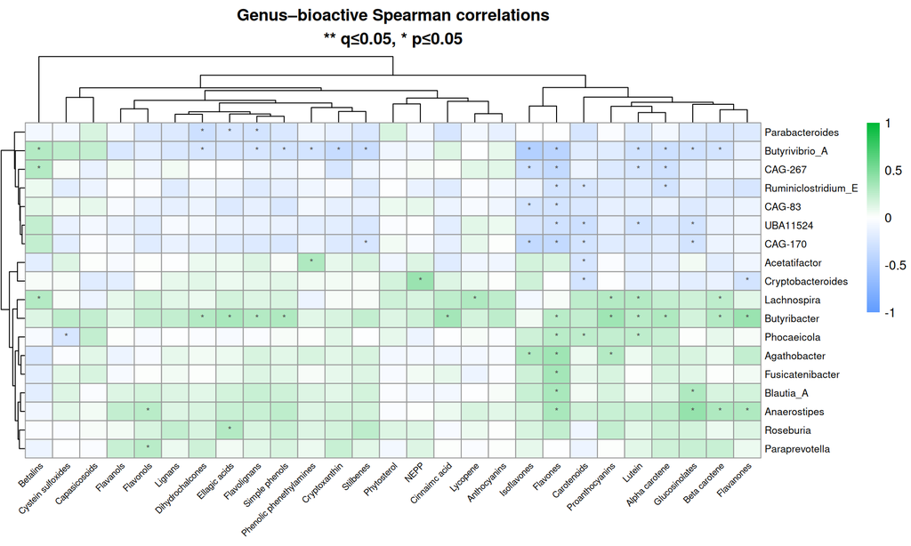

```r
# There are too few genera with a significant q-value, let's just use p-values for this tutorial.
message("Too few genera pass q <= 0.05 — relaxing to p <= 0.05 for illustration")
sig_genera <- pairs |> filter(pval <= 0.05) |> pull(genus) |> unique()

# Build rho matrix and significance label matrix for significant genera
tbl_sig <- pairs |> filter(genus %in% sig_genera)

rho_mat <- tbl_sig |>
  pivot_wider(id_cols = genus, names_from = bioactive, values_from = rho) |>
  column_to_rownames("genus") |>
  as.matrix()

sig_labels <- tbl_sig |>
  mutate(label = case_when(
    qval  <= 0.05 ~ "**",
    pval  <= 0.05 ~ "*",
    TRUE          ~ ""
  )) |>
  pivot_wider(id_cols = genus, names_from = bioactive, values_from = label) |>
  column_to_rownames("genus") |>
  as.matrix()

# Rename genera to short names for readability
rownames(rho_mat)   <- map_chr(rownames(rho_mat), trim_to_genus)
rownames(sig_labels) <- rownames(rho_mat)

pheatmap::pheatmap(
  rho_mat,
  display_numbers = sig_labels,
  cluster_cols    = TRUE,
  cluster_rows    = TRUE,
  breaks          = seq(-1, 1, length.out = 101),
  color           = colorRampPalette(c("#619CFF", "white", "#00BA38"))(100),
  fontsize_row    = 8,
  fontsize_col    = 7,
  angle_col       = 45,
  treeheight_row  = 15,
  main = "Genus–bioactive Spearman correlations\n** q≤0.05, * p≤0.05"
)
```

Try redoing some of these graphs but just for the low bioactive or high bioactive arms of the study. Do you spot anything?

Finally, as an exercise you can try redoing the heatmap but with SCFA data instead of bioactives. (Code is below in case you get stuck.)

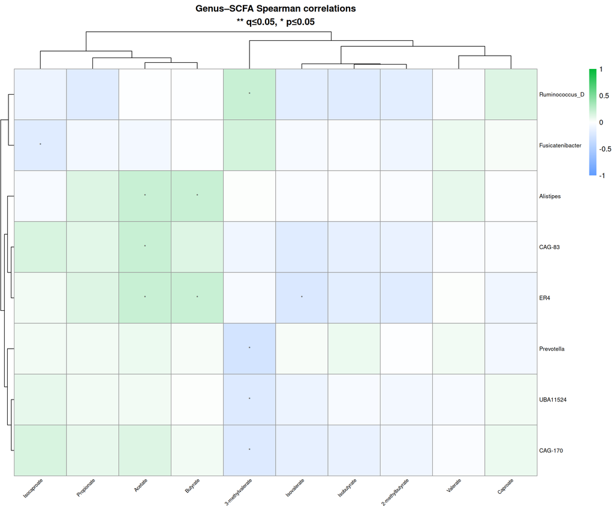

```r
sample_ids <- tbl_md |> pull("sample_id")

genus_filt <- genus_rel[top_genera, sample_ids]
scfa_all <- tbl_scfa |> filter(ID %in% sample_ids) |> column_to_rownames("ID") |> t()


pairs <- expand.grid(
  genus    = rownames(genus_filt),
  scfa = rownames(scfa_all),
  stringsAsFactors = FALSE
)

corr_results <- mapply(
  FUN = function(g, s) {
    res <- cor.test(
      as.numeric(genus_filt[g, ]),
      as.numeric(scfa_all[s, ]),
      method = "spearman"
    )
    c(rho = unname(res$estimate), pval = res$p.value)
  },
  pairs$genus, pairs$scfa,
  SIMPLIFY = TRUE
) |> t() |> as.data.frame()

pairs$rho  <- corr_results$rho
pairs$pval <- corr_results$pval
pairs$qval <- p.adjust(pairs$pval, method = "BH")

sig_genera <- pairs |> filter(pval <= 0.05) |> pull(genus) |> unique()

# Build rho matrix and significance label matrix for significant genera
tbl_sig <- pairs |> filter(genus %in% sig_genera)

rho_mat <- tbl_sig |>
  pivot_wider(id_cols = genus, names_from = scfa, values_from = rho) |>
  column_to_rownames("genus") |>
  as.matrix()

sig_labels <- tbl_sig |>
  mutate(label = case_when(
    qval  <= 0.05 ~ "**",
    pval  <= 0.05 ~ "*",
    TRUE          ~ ""
  )) |>
  pivot_wider(id_cols = genus, names_from = scfa, values_from = label) |>
  column_to_rownames("genus") |>
  as.matrix()

# Rename genera to short names for readability
rownames(rho_mat)   <- map_chr(rownames(rho_mat), trim_to_genus)
rownames(sig_labels) <- rownames(rho_mat)

pheatmap::pheatmap(
  rho_mat,
  display_numbers = sig_labels,
  cluster_cols    = TRUE,
  cluster_rows    = TRUE,
  breaks          = seq(-1, 1, length.out = 101),
  color           = colorRampPalette(c("#619CFF", "white", "#00BA38"))(100),
  fontsize_row    = 8,
  fontsize_col    = 7,
  angle_col       = 45,
  treeheight_row  = 15,
  main = "Genus–SCFA Spearman correlations\n** q≤0.05, * p≤0.05"
)
```

## Recap

We’ve done a lot of exploring the data. This is useful because in the next sessions we’ll be looking at much more abstract / complicated analyses. So, you’ll likely want to relate what you see in those analyses back to this much simpler analysis where you’re looking at a ‘raw’ version of the data.

| Step | Function | What it does |
| --- | --- | --- |
| Relative abundance | `prop.table(margin = 2)` | Converts read counts to per-sample proportions |
| Pivot to long form | `pivot_longer()` | Reshapes wide matrix to ggplot-friendly format |
| Wilcoxon signed-rank | `ggpubr::stat_compare_means(paired = TRUE)` | Pairwise test on paired (crossover) samples |
| Heatmap | `pheatmap::pheatmap()` | Clustered heatmap with optional cell annotations |
| Pairwise correlations | `cor.test(method = "spearman")` | Spearman rho + p-value per pair |
| Multiple testing | `p.adjust(method = "BH")` | Benjamini–Hochberg FDR correction across all pairs |